# Motor Trend: Will type of transmission have an impact on the MPG of a car?

## Executive Summary

Motor Trend is interested interested in exploring the relationship between a set of variables and miles per gallon (MPG). For this, we analyze dataset mtcars and will answer the below two questions specifically: . “Is an automatic or manual transmission better for MPG” . “Quantify the MPG difference between automatic and manual transmissions”

Based on the linear regression analysis we conclude that the MPG for cars with manual transmission is better than the cars with automatic transmission. The mpg increases by 1.8 when manual transmission is used instead of automatic transmission.

### I. Data Processing

Loading mtcars dataset and transforming subset of variables into factor variables. Transformation of variables to factor variables is decided by looking at the various values the variables take

```r
data(mtcars)
mtcars$cyl  <-  factor(mtcars$cyl)
mtcars$vs   <-  factor(mtcars$vs)
mtcars$am   <-  factor(mtcars$am, labels = c("Automatic","Manual"))
mtcars$gear <-  factor(mtcars$gear)
mtcars$carb <-  factor(mtcars$carb)
```

### II. Exploratory Analysis

As part of exploratory analysis we explore relationship among all the variables in the mtcar dataset.

Inaddition to this, since we are interested in outlining relationship between MPG and type of transmission, we use a box plot to understand this better.

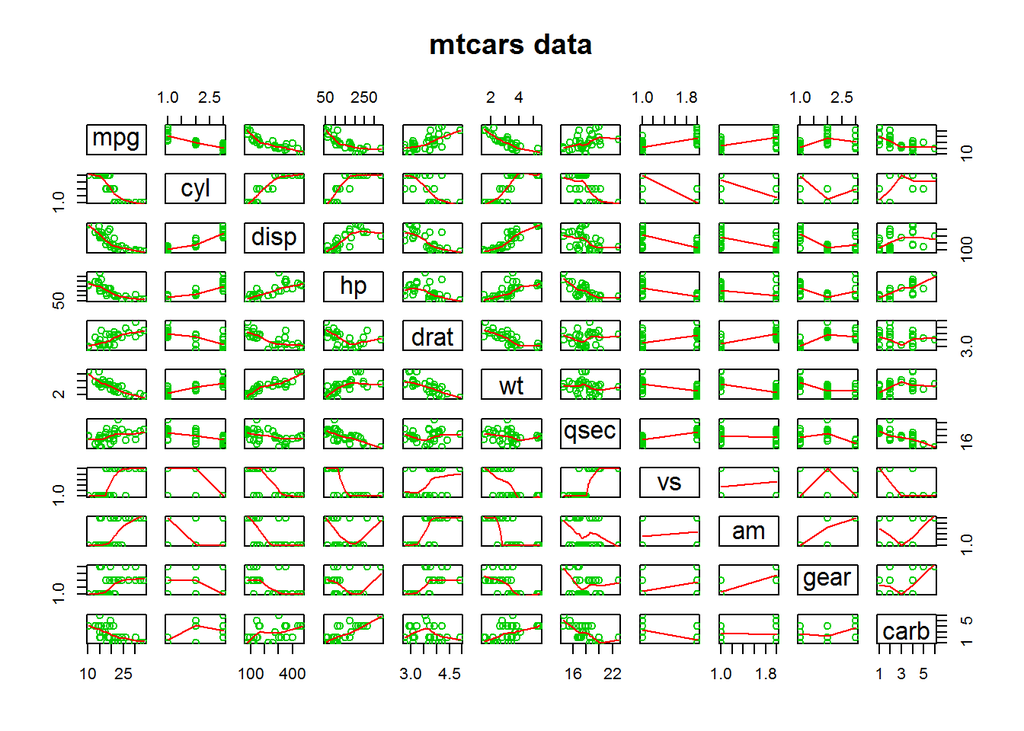

```r
pairs(mtcars, panel=panel.smooth, main = "mtcars data", col=3)
```

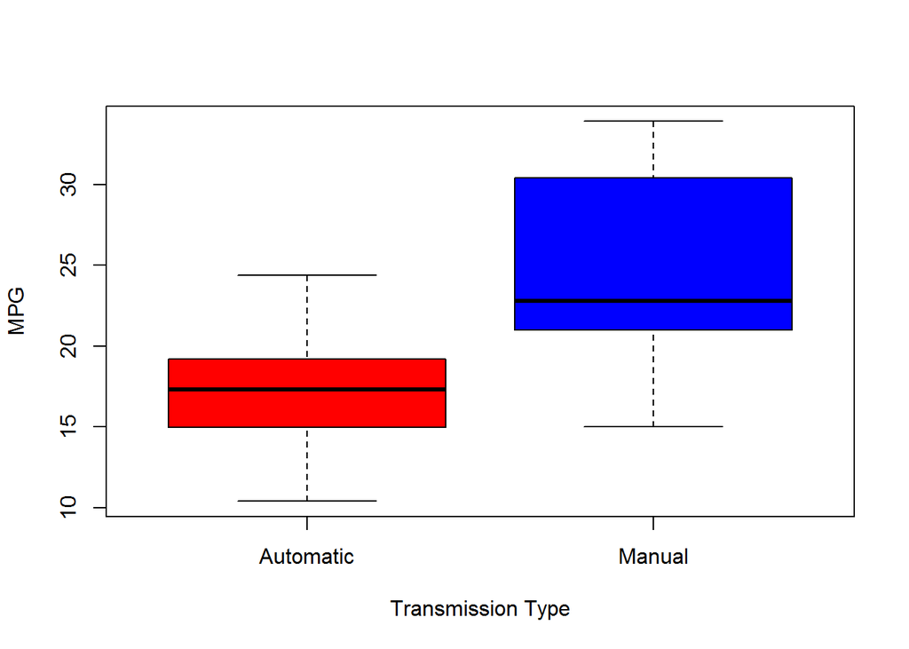

```r
boxplot(mpg ~ am, data = mtcars, col=c("red","blue"), ylab= "MPG", xlab= "Transmission Type")
```

### Observations from Exploratory Analysis

**From the first plot it is clear that there is a strong correlation between mpg and variables cyl, dsp, hp,wt, vs and am**

**From the box plot, it is clears that the mpg from manual transimission is higher than that of automatic transmission**